# Analisis De Componentes Principales

Miguel Albertí Pons, Iker González Cuellar, Pol Martínez Collado

15-03-23

```r
library(ggplot2)
library(reshape2)
library(tidyr)
library(dplyr)
library(GGally)
library(FactoMineR)
```

#### 1. Lea el fichero “churn.txt”. Efectúe las correcciones del fichero de datos ya realizadas para el ejercicio de “Profiling”. Razone lo que significa realizar un ACP con datos estandarizados o sin estandarizar.

```r
data = read.table("_repository/churn.txt",header=T)

data$sexo[data$sexo == 'No informado'] = 'MUJER'
data$Nomina = replace(data$Nomina, is.na(data$Nomina), 'Nomina NO')
data$Pension = replace(data$Pension, is.na(data$Pension), 'Pension NO')
data$Debito_aff = replace(data$Debito_aff, is.na(data$Debito_aff), 'Debito aff. NO')
data$VISA = replace(data$VISA, is.na(data$VISA), 'VISA NO')
data$MCard = replace(data$MCard, is.na(data$MCard), 'MCard NO')
dim(data)
```

```
## [1] 2000   30
```

Al realizar un ACP y estandarizar los datos, significa que las variables se normalizan, centrándolas y con una desviación tipo igual a 1, de esta forma los valores se ponen en una misma escala para ser comparables y evitar cualquier sesgo por valores atípicos muy elevados. Por el otro lado, el no estandarizar los datos, el análisis se podrá ver afectado en caso de que las valores no estén en una misma escala ya que los valores atípicos podrán sesgar el análisis.

```r
#ggpairs(data, columns = 30)
```

#### 2. Efectúe un Análisis de Componentes Principales estandarizado, tomando como variables activas los productos bancarios antes especificados. Declare como ilustrativos los clientes que se dieron de baja (de esta forma la configuración obtenida reflejará la de los clientes “normales”).

```r
index_NoBaja = which(data$Baja == 'Baja NO')

cp = PCA(data, quanti.sup = c(13:17), quali.sup = c(1:3,5:12,18), ind.sup = index_NoBaja)
```

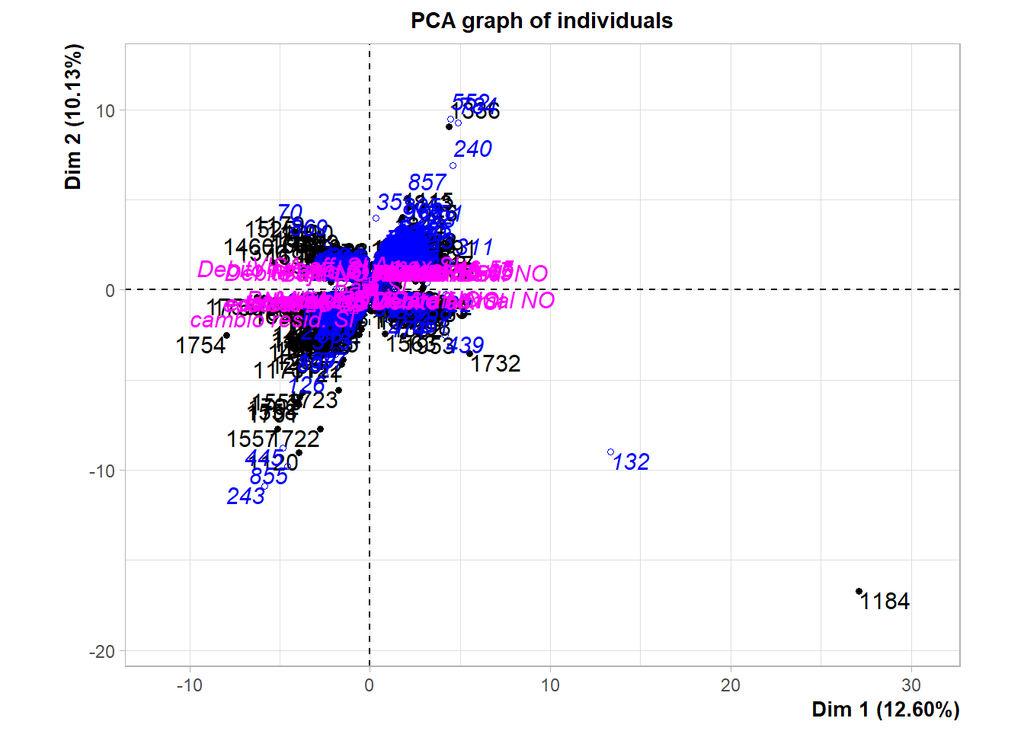

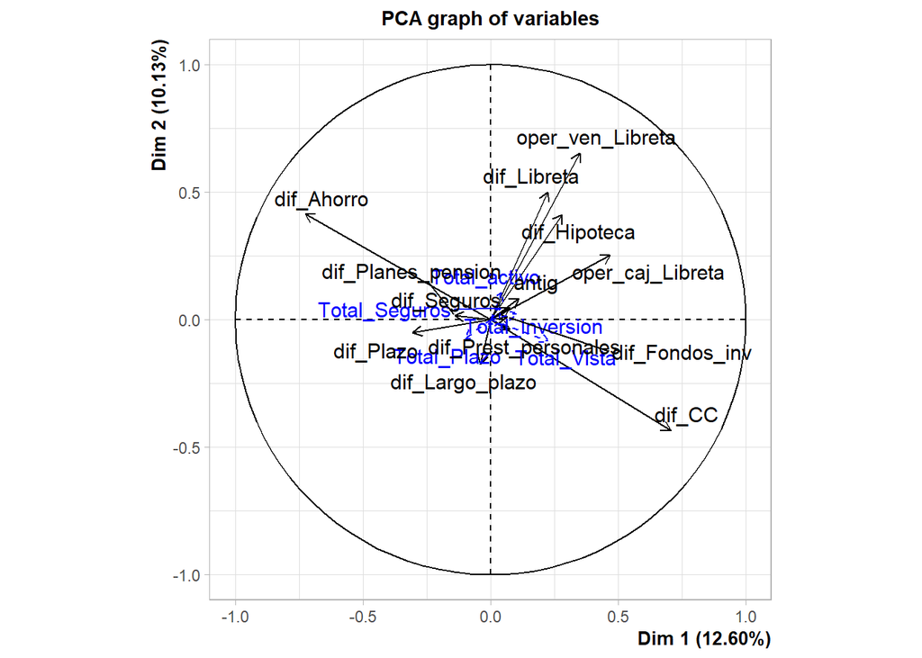

#### 3. Obtenga la representación gráfica del “Screeplot” (diagrama de los “eigenvalues”) y a la vista de las correlaciones entre las variables originales y las componentes principales, decida el número de dimensiones significativas. ¿Cuál es el porcentaje de variancia retenido?.

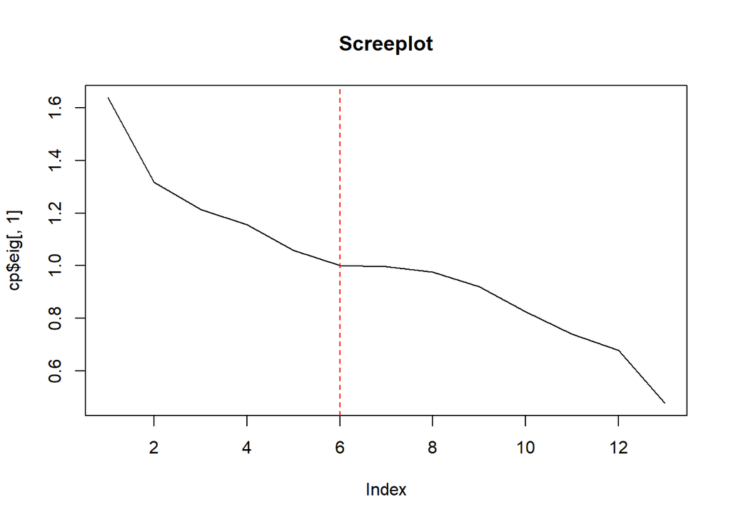

```r
plot(cp$eig[,1], type='l', main = 'Screeplot')
abline(v = 6, col = 'red', lty = 2)
```

```r
cp$eig
```

```
##         eigenvalue percentage of variance cumulative percentage of variance
## comp 1   1.6383361              12.602585                          12.60259
## comp 2   1.3175497              10.134997                          22.73758
## comp 3   1.2135446               9.334959                          32.07254
## comp 4   1.1547046               8.882343                          40.95488
## comp 5   1.0587987               8.144606                          49.09949
## comp 6   1.0006586               7.697374                          56.79686
## comp 7   0.9969582               7.668909                          64.46577
## comp 8   0.9766656               7.512812                          71.97858
## comp 9   0.9205363               7.081048                          79.05963
## comp 10  0.8257524               6.351941                          85.41157
## comp 11  0.7404066               5.695435                          91.10701
## comp 12  0.6786518               5.220398                          96.32741
## comp 13  0.4774369               3.672592                         100.00000
```

El número de dimensiones significativas sería 6, ya que en el screeplot se puede observar el último ángulo convexo (“last elbow”) en dicha dimensión, obteniendo un porcentaje de variancia retenido del 56.80%. A partir de la dimensión 6, el resto de dimensiones se pueden considerar ruido aleatorio.

#### 4. Efectúe una rotación “varimax” para hacer más evidente los factores latentes (intangibles) presentes en sus datos activos. ¿Cuáles son en este caso estos factores latentes?.

```r
cp_rot = varimax(cp$var$cor)
cp_rot$loadings
```

```
##
## Loadings:
##                      Dim.1  Dim.2  Dim.3  Dim.4  Dim.5
## antig                        0.128         0.127  0.166
## oper_caj_Libreta      0.113  0.270 -0.640  0.145
## oper_ven_Libreta             0.718 -0.181
## dif_CC                0.866                       0.116
## dif_Libreta                  0.696  0.300         0.156
## dif_Plazo                           0.682  0.129 -0.120
## dif_Ahorro           -0.854         0.126
## dif_Largo_plazo             -0.184 -0.223  0.754
## dif_Fondos_inv              -0.105 -0.224 -0.379  0.519
## dif_Seguros                        -0.272 -0.495
## dif_Planes_pension                        -0.365 -0.633
## dif_Hipoteca                 0.456 -0.264        -0.280
## dif_Prest_personales                              0.498
##
##                Dim.1 Dim.2 Dim.3 Dim.4 Dim.5
## SS loadings    1.509 1.354 1.274 1.161 1.085
## Proportion Var 0.116 0.104 0.098 0.089 0.083
## Cumulative Var 0.116 0.220 0.318 0.408 0.491
```

Los factores latentes serían los siguientes:

- **Dim. 1**: dif_CC, dif_Ahorro
  - Distingue las personas con cambios en el estado de su cuenta corriente de aquellos con cambios en sus fondos de ahorro.
- **Dim.2**: oper_ven_Libreta, dif_Libreta
  - Agrupa a las personas que operan sobre su libreta a nivel de ventanilla con los cambios a través de sus libretas en sus respectivas cuentas corriente (extracciones/ingresos) respecto a los 3 meses y al año anterior.

  **Dim.3**: oper_caj_Libreta, dif_Plazo
  - Distingue aquellas personas con cambios (últimos 3 meses y 1 año) en sus productos a plazos de aquellas que operan con libreta en los cajeros.
- **Dim.4**: dif_Largo_plazo
  - Identifica aquellas personas con cambios (últimos 3 meses y 1 año) en sus productos a largo plazo.
- **Dim.5**: dif_Fondos_inv, dif_Planes_pension
  - Distingue aquellas personas con cambios (últimos 3 meses y 1 año) en su fondo de pensión con aquellos con aquellos que invierten en fondos de inversión.

#### 5. Represente gráficamente la nube de puntos individuo activos. Sobre esta nube proyecte los individuos suplementarios. ¿Piensa Ud. que la configuración de los clientes que han sido baja es distinta de la de los clientes que no han sido baja?. Haga la representación solamente en el primer plano factorial (ejes 1 y 2).

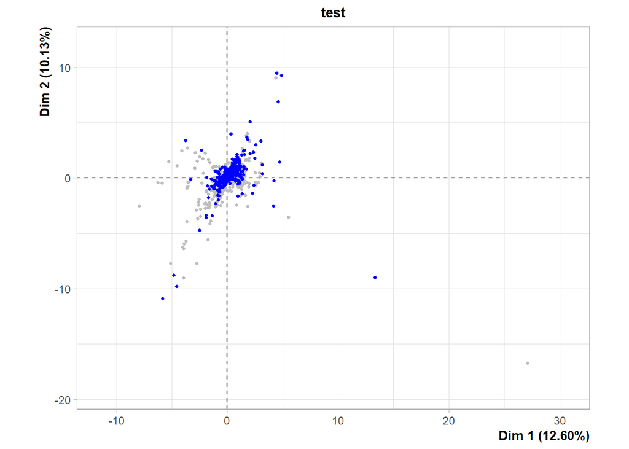

```r
plot(cp, axes = c(1,2), choix = c('ind'), title = "test", cex = 0.7, col.ind = 'gray', col.ind.sup = 'blue', label = 'none', invisible = 'quali')
```

La configuración de los clientes que han sido baja no es distinta de los clientes que no han sido baja ya que en el gráfico, ambas nubes están sobre puestas y no desplazadas.